# IMDB - Movie Ratings

Rajiv

26 November 2016

# STEP - 1: Data Collection for the Movie Reviews and Ratings

Loading the *rvest* Package necessary to scrape the data from the web

We are Scraping the user reviews and ratings in the below code for the selected Movie. A sample of couple reviews are displayed.

```r
counts = c(0,10,20,30,40)
reviews = NULL
ratings = NULL

for (j in counts){

  url1 = paste0("http://www.imdb.com/title/tt0454921/reviews?filter=love;filter=love;start=",j)
  url2 = paste0("http://www.imdb.com/title/tt0454921/reviews?filter=hate;filter=hate;start=",j)

  page1 = read_html(url1)
  page2 = read_html(url2)

  reviews1 = html_text(html_nodes(page1,'#tn15content p'))
  reviews2 = html_text(html_nodes(page2,'#tn15content p'))

  reviews.positive = setdiff(reviews1, c("*** This review may contain spoilers ***","Add another review"))
  reviews.negative = setdiff(reviews2, c("*** This review may contain spoilers ***","Add another review"))

  reviews = c(reviews,reviews.positive,reviews.negative)

  ratings.positive = substr(html_attr(html_nodes(page1,'h2+ img'),name = 'alt'),0,2)
  ratings.negative = substr(html_attr(html_nodes(page2,'h2+ img'),name = 'alt'),0,1)

  ratings = c(ratings,ratings.positive,ratings.negative)
}
reviews = gsub("\n",' ',reviews) #writeLines(reviews,'Game of Thrones IMDB reviews.txt')
head(reviews,2)
```

```
## [1] " I was blessed to have seen this movie last night. It made me laugh, it made me cry and it made me love life. This movie is a great movie that depicts a love of a father for his son. Will Smith did an incredible job and deserves every accolade available to him. His son also did a fantastic j…
## [2] " They just don't make many this good. The audience and I cried, laughed, cheered and applauded. The climactic scene is as powerful and cathartic as The Shawshank Redemption's golden moment. Will Smith is terrific, his son Jaden is just perfect, and Thandie Newton puts in a convincing support…
```

# STEP - 2: Analysing the Data Collected

Loading required packages for Text Analysis

Loaded the required Packages: text2vec, data.table, stringr, tm, RWeka, tokenizers, slam, wordcloud, ggplot2

Creating a Data Frame from the reviews and ratings of the data collected. In this DataFrame We create a column id for each user review, the actual user review column and the user rating column

```r
data = data.frame(id = 1:length(reviews),  # creating doc IDs if name is not given
                  text = reviews,
                  stars = ratings,
                  stringsAsFactors = F)
```

The structure and the data frame that we created is displayed below

```r
dim(data)   #head(data,2)
```

```
## [1] 100   3
```

The default stopwords from the file given in the class is imported from the Git page. The stopwords from the “text mining (TM)” package are imported. Additional stop words that are necessary for determining actual context are deleted by creating a seperate variable.

```r
stpw1 = readLines('https://raw.githubusercontent.com/sudhir-voleti/basic-text-analysis-shinyapp/master/data/stopwords.txt')
stpw2 = tm::stopwords('english')
stpw3 = c('movie','film','pursuit','happyness','happiness','chris','gartner', 'smith')
comn  = unique(c(stpw1, stpw2,stpw3))
stopwords = unique(gsub("'"," ",comn))
```

A function used to format all the movie reviews data is defined here.

```r
text.clean = function(x)                    # text data
{ #require("tm")
    x  =  gsub("<.*?>", " ", x)               # regex for removing HTML tags
    x  =  iconv(x, "latin1", "ASCII", sub="") # Keep only ASCII characters
    x  =  gsub("[^[:alnum:]]", " ", x)        # keep only alpha numeric
    x  =  tolower(x)                          # convert to lower case characters
    x  =  removeNumbers(x)                    # removing numbers
    x  =  stripWhitespace(x)                  # removing white space
    x  =  gsub("^\\s+|\\s+$", "", x)          # remove leading and trailing white space
    return(x)
}
```

Finaly a cleaned corpus without any special characters, Unicode characters, numbers etc.., along with the stopwords that were defined above removed from all the documents with the white spaces cleaned is returned.

A sample of two reviews of the cleaned corpus is displayed.

```r
x  = text.clean(data$text)
x  =  removeWords(x,stopwords)
x  =  stripWhitespace(x)
head(x,2)
```

```
## [1] " blessed night made laugh made cry made love life great depicts love father son incredible job deserves accolade son fantastic job great lesson learned shares struggles everyday life heart felt touching experience worth making forward "
## [2] " make good audience cried laughed cheered applauded climactic scene powerful cathartic shawshank redemption golden moment terrific son jaden perfect thandie newton puts convincing supporting act san francisco absorbing authentic stealing show thinker challenge visions family business society…
```

# STEP - 3: Create DTM using text2vec package

We are first creating bigrams from the corpus and picking the bigrams that only apper atleaset a minimum of 5 times in the whole corpus. In the next step replacing these bigrams in our original corpus and then tokenizing with the Uni-Grams.

From here we take all the word tokens and their frequencies and then create a DTM out of it. The Output of the final DTM will be like, each token and it’s frequency in the each document.

The structure of the DTM and subset of word tokens and their document frequencies are displayed.

```r
tok_fun = word_tokenizer
it_0 = itoken( x,tokenizer = tok_fun,ids = data$id,progressbar = F)
vocab = create_vocabulary(it_0,ngram = c(2L, 2L))  #length(vocab); str(vocab) # view what vocab obj is like #head(vocab,5)
pruned_vocab = prune_vocabulary(vocab,term_count_min = 5) # length(pruned_vocab);  str(pruned_vocab)
vectorizer = vocab_vectorizer(pruned_vocab)
dtm_0  = create_dtm(it_0, vectorizer)
#dim(dtm_0)
# Sort bi-gram with decreasing order of freq
tsum = as.matrix(t(rollup(dtm_0, 1, na.rm=TRUE, FUN = sum))) # find sum of freq for each term
tsum = tsum[order(tsum, decreasing = T),]       # terms in decreasing order of freq
#head(tsum,5)
#tail(tsum,5)

# Code bi-grams as unigram in clean text corpus
text2 = x
text2 = paste("",text2,"")
pb <- txtProgressBar(min = 1, max = (length(tsum)), style = 3) ; i = 0
for (term in names(tsum)){
    i = i + 1
    focal.term = gsub("_", " ",term)
    replacement.term = term
    text2 = gsub(paste("",focal.term,""),paste("",replacement.term,""), text2)
    #setTxtProgressBar(pb, i)
}
it_m = itoken(text2,tokenizer = tok_fun,ids = data$id,progressbar = F)
vocab = create_vocabulary(it_m) # length(vocab); str(vocab)     # view what vocab obj is like
pruned_vocab = prune_vocabulary(vocab,term_count_min = 1)
vectorizer = vocab_vectorizer(pruned_vocab)
dtm_m  = create_dtm(it_m, vectorizer) #dim(dtm_m)
dtm = as.DocumentTermMatrix(dtm_m, weighting = weightTf)
a0 = (apply(dtm, 1, sum) > 0)   # build vector to identify non-empty docs
dtm = dtm[a0,]                  # drop empty docs
dim(dtm)
```

```
## [1]  100 2493
```

```r
# view a sample of the DTM, sorted from most to least frequent tokens
dtm = dtm[,order(apply(dtm, 2, sum), decreasing = T)]     # sorting dtm's columns in decreasing order of column sums
inspect(dtm[1:5, 1:5])     # inspect() func used to view parts of a DTM object
```

```
## <<DocumentTermMatrix (documents: 5, terms: 5)>>
## Non-/sparse entries: 10/15
## Sparsity           : 60%
## Maximal term length: 5
## Weighting          : term frequency (tf)
##
##     Terms
## Docs son life story good great
##    1   1    2     0    0     2
##    2   0    0     1    1     2
##    3   1    0     0    0     0
##    4   0    0     0    1     4
##    5   1    0     0    0     0
```

**Plotting Word Cloud and Bar graph for a Term Frequency (TF) Matrix**

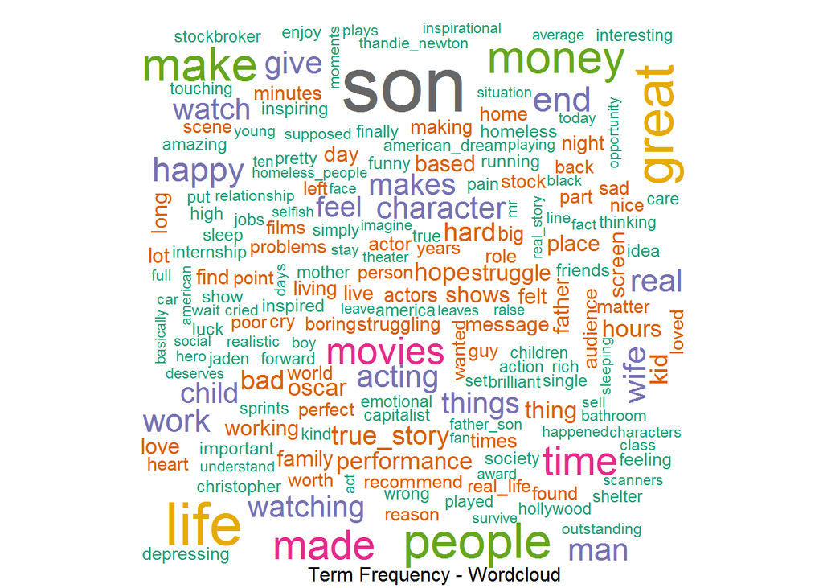

```r
tst = round(ncol(dtm)/100)  # divide DTM's cols into 100 manageble parts
a = rep(tst,99)
b = cumsum(a);rm(a)
b = c(0,b,ncol(dtm))
ss.col = c(NULL)
for (i in 1:(length(b)-1)) {
    tempdtm = dtm[,(b[i]+1):(b[i+1])]
    s = colSums(as.matrix(tempdtm))
    ss.col = c(ss.col,s)
    #print(i)
}
tsum = ss.col
tsum = tsum[order(tsum, decreasing = T)] #terms in decreasing order of freq
#head(tsum)
#tail(tsum)
#names(tsum)
#tsum
#windows()
wordcloud(names(tsum), tsum,scale = c(4, 0.5),1,max.words = 200,colors = brewer.pal(8, "Dark2"))
title(sub = "Term Frequency - Wordcloud")
```

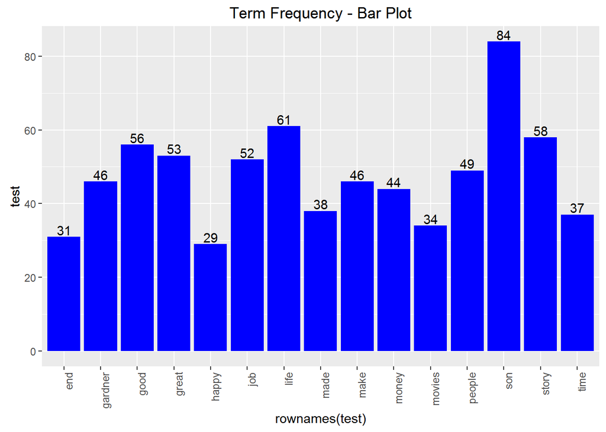

```r
test = as.data.frame(round(tsum[1:15],0))
#windows()
ggplot(test, aes(x = rownames(test), y = test)) +
geom_bar(stat = "identity", fill = "Blue") +
geom_text(aes(label = test), vjust= -0.20) +
theme(axis.text.x = element_text(angle = 90, hjust = 1))+
ggtitle("Term Frequency - Bar Plot")
```

**Plotting Word Cloud and Bar Grapg Using a Term frequency inverse document frequency (tfidf)**

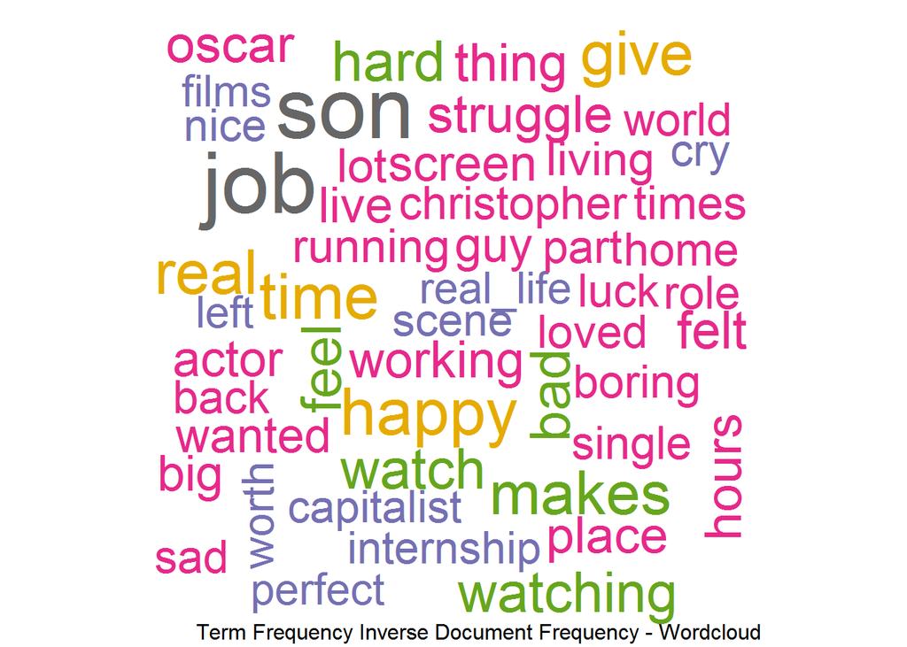

```r
dtm.tfidf = tfidf(dtm, normalize=FALSE)
tst = round(ncol(dtm.tfidf)/100)
a = rep(tst, 99)
b = cumsum(a);rm(a)
b = c(0,b,ncol(dtm.tfidf))

ss.col = c(NULL)
for (i in 1:(length(b)-1)) {
    tempdtm = dtm.tfidf[,(b[i]+1):(b[i+1])]
    s = colSums(as.matrix(tempdtm))
    ss.col = c(ss.col,s)
    #print(i)
}
tsum = ss.col
tsum = tsum[order(tsum, decreasing = T)]
#head(tsum)
#tail(tsum)
#windows()
wordcloud(names(tsum), tsum, scale=c(4,1),1, max.words=110,colors=brewer.pal(8, "Dark2"))
title(sub = "Term Frequency Inverse Document Frequency - Wordcloud")
```

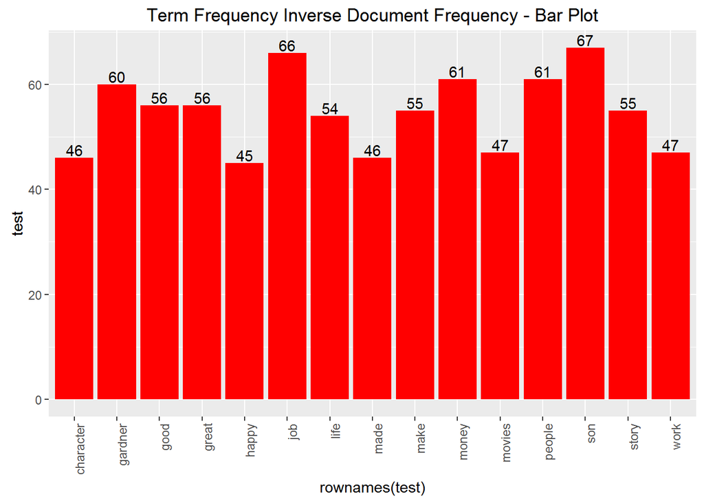

```r
#as.matrix(tsum[1:20])
#(dtm.tfidf)[1:10, 1:10]
test = as.data.frame(round(tsum[1:15],0))
#windows()
ggplot(test, aes(x = rownames(test), y = test)) +
    geom_bar(stat = "identity", fill = "red") +
    geom_text(aes(label = test), vjust= -0.20) +
    theme(axis.text.x = element_text(angle = 90, hjust = 1)) +
    ggtitle("Term Frequency Inverse Document Frequency - Bar Plot")
```

**Creating a Term Co-Occurance Matrix (TCM) and Creating a COG**

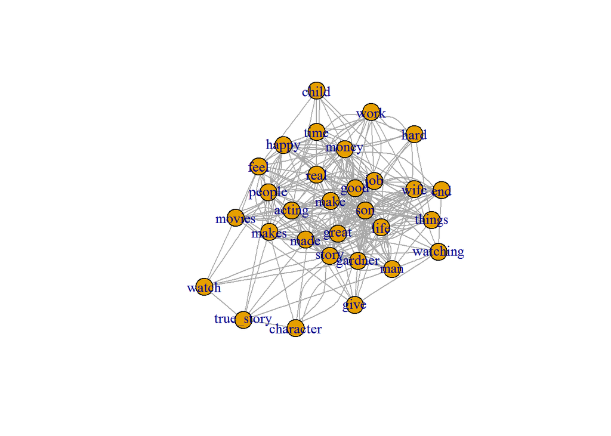

```r
vectorizer = vocab_vectorizer(pruned_vocab,grow_dtm = FALSE,skip_grams_window = 5L)
tcm = create_tcm(it_m, vectorizer)
tcm.mat = as.matrix(tcm)
adj.mat = tcm.mat + t(tcm.mat)
z = order(colSums(adj.mat), decreasing = T)
adj.mat = adj.mat[z,z]
adj = adj.mat[1:30,1:30]
cog = graph.adjacency(adj, mode = 'undirected')
#cog =  simplify(cog)
cog = delete.vertices(cog, V(cog)[ degree(cog) == 0 ])
#windows()
plot(cog)
```

**Distilled COG plots using an user defiend function for TF and TFIDF**

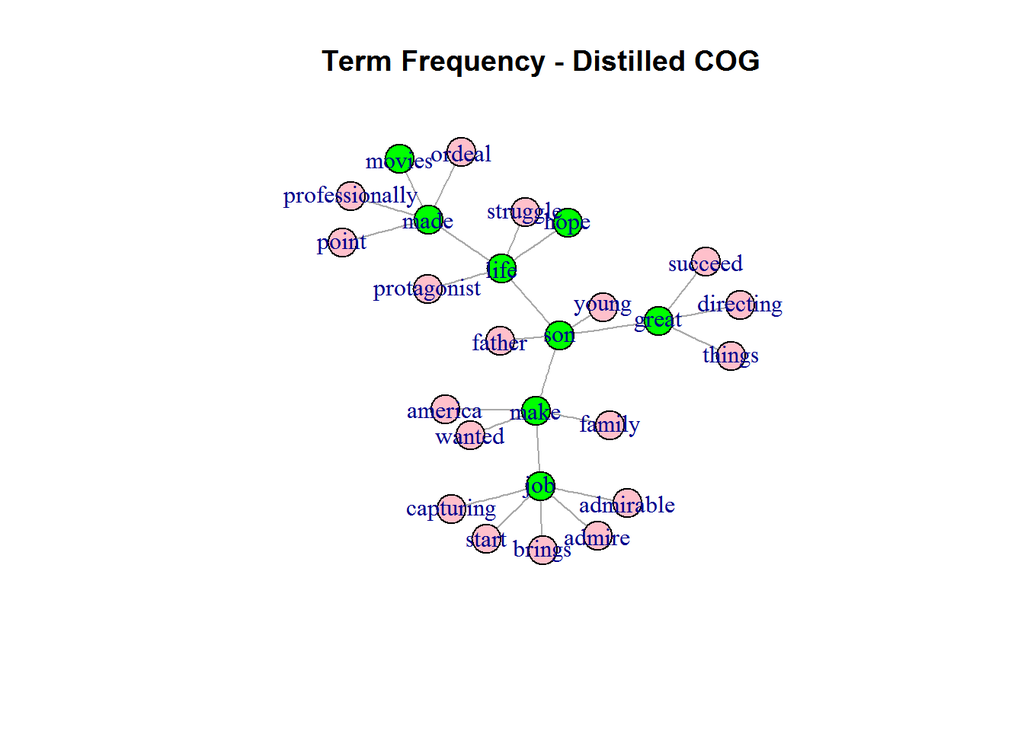

```r
distill.cog = function(mat1,title,s,k1){
    a = colSums(mat1)
    b = order(-a)
    mat2 = mat1[b, b]
    diag(mat2) =  0
    wc = NULL
    for (i1 in 1:s){
        thresh1 = mat2[i1,][order(-mat2[i1, ])[k1]]
        mat2[i1, mat2[i1,] < thresh1] = 0   # neat. didn't need 2 use () in the subset here.
        mat2[i1, mat2[i1,] > 0 ] = 1
        word = names(mat2[i1, mat2[i1,] > 0])
        mat2[(i1+1):nrow(mat2), match(word,colnames(mat2))] = 0
        wc = c(wc,word)
    }
    mat3 = mat2[match(wc, colnames(mat2)), match(wc, colnames(mat2))]
    ord = colnames(mat2)[which(!is.na(match(colnames(mat2), colnames(mat3))))]  # removed any NAs from the list
    mat4 = mat3[match(ord, colnames(mat3)), match(ord, colnames(mat3))]
    graph <- graph.adjacency(mat4, mode = "undirected", weighted=T)    # Create Network object
    graph = simplify(graph)
    V(graph)$color[1:s] = "green"
    V(graph)$color[(s+1):length(V(graph))] = "pink"
    graph = delete.vertices(graph, V(graph)[ degree(graph) == 0 ]) # delete singletons?
    plot(graph,layout = layout.kamada.kawai,main = title)
}
#windows()
distill.cog(tcm.mat, 'Term Frequency - Distilled COG',  10,  4)
```

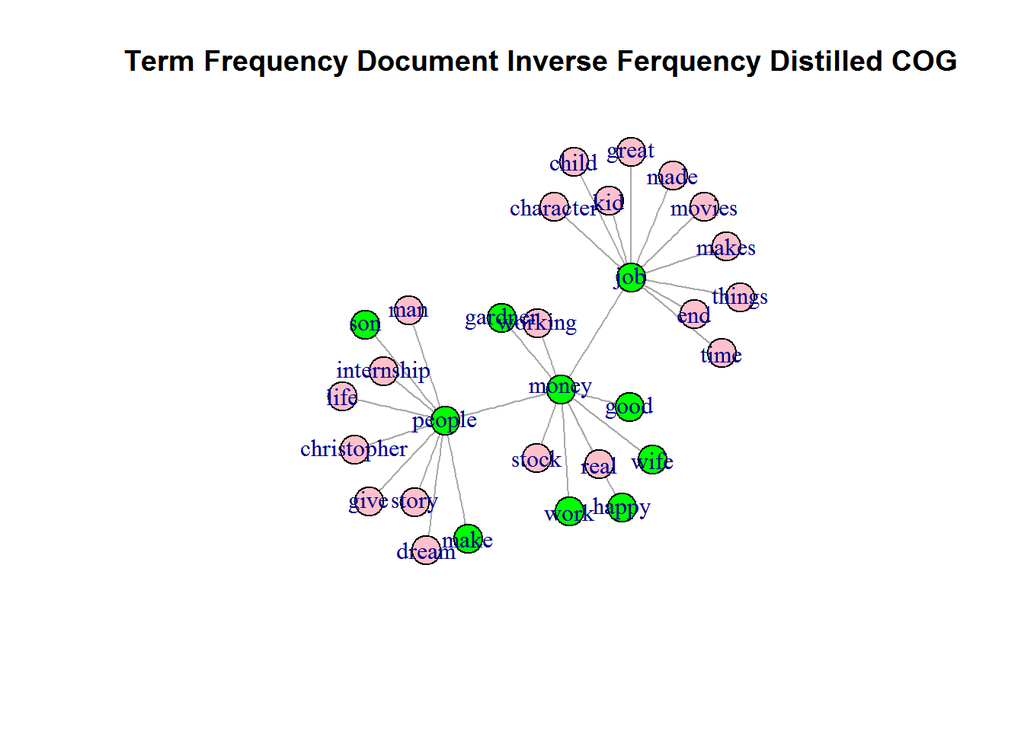

```r
## adj.mat and distilled cog for tfidf DTMs ##
adj.mat = t(dtm.tfidf) %*% dtm.tfidf
diag(adj.mat) = 0
a0 = order(apply(adj.mat, 2, sum), decreasing = T)
adj.mat = as.matrix(adj.mat[a0[1:30], a0[1:30]])
#windows()
distill.cog(adj.mat, 'Term Frequency Document Inverse Ferquency Distilled COG',  10,  10)
```

## Step - 4: Compare corelation between review polarity score with its star rating

```r
pol = polarity(x)
pol_score =  pol$all$polarity
data$stars = as.numeric(data$stars)
cor(pol_score,data$stars)
```

```
## [1] 0.5188112
```

The positive and Negative words that were talked about the movie are displayed in the below wordcloud.

```r
it_senti = itoken(x,tokenizer = tok_fun,ids = data$id,progressbar = F)
vocab_senti = create_vocabulary(it_senti)
pruned_vocab_senti = prune_vocabulary(vocab_senti,term_count_min = 1)
vectorizer_senti = vocab_vectorizer(pruned_vocab_senti)
dtm_senti  = create_dtm(it_senti, vectorizer_senti)
#dim(dtm_m)
dtm_1 = as.DocumentTermMatrix(dtm_senti, weighting = weightTf)
a0 = (apply(dtm_1, 1, sum) > 0)   # build vector to identify non-empty docs
dtm_1 = dtm_1[a0,]                  # drop empty docs
positive_words = unique(setdiff(unlist(pol$all[,4]),"-"))  # Positive words list
negative_words = unique(setdiff(unlist(pol$all[,5]),"-"))  # Negative words list
```

```r
head(positive_words,15)
```

```
##  [1] "love"       "great"      "incredible" "accolade"   "fantastic"
##  [6] "worth"      "good"       "powerful"   "redemption" "golden"
## [11] "terrific"   "perfect"    "convincing" "supporting" "authentic"
```

```r
head(negative_words,15)
```

```
##  [1] "cry"          "struggles"    "stealing"     "myth"
##  [5] "false"        "burning"      "indignation"  "struggle"
##  [9] "cynical"      "disappointed" "hard"         "warned"
## [13] "pain"         "shame"        "unbearable"
```

**Wordclouds**

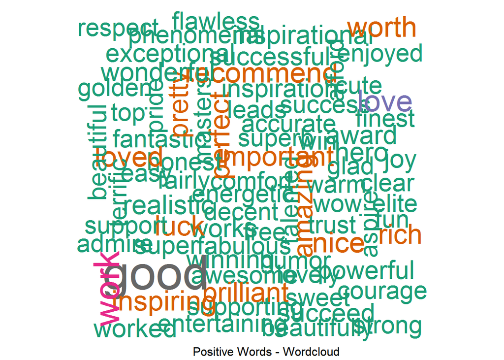

```r
pos.tdm = dtm[,which(colnames(dtm) %in% positive_words)]
m = as.matrix(pos.tdm)
v = sort(colSums(m), decreasing = TRUE)
windows() # opens new image window
wordcloud(names(v), v, scale=c(4,2),1, max.words=100,colors=brewer.pal(8, "Dark2"))
title(sub = "Positive Words - Wordcloud")
```

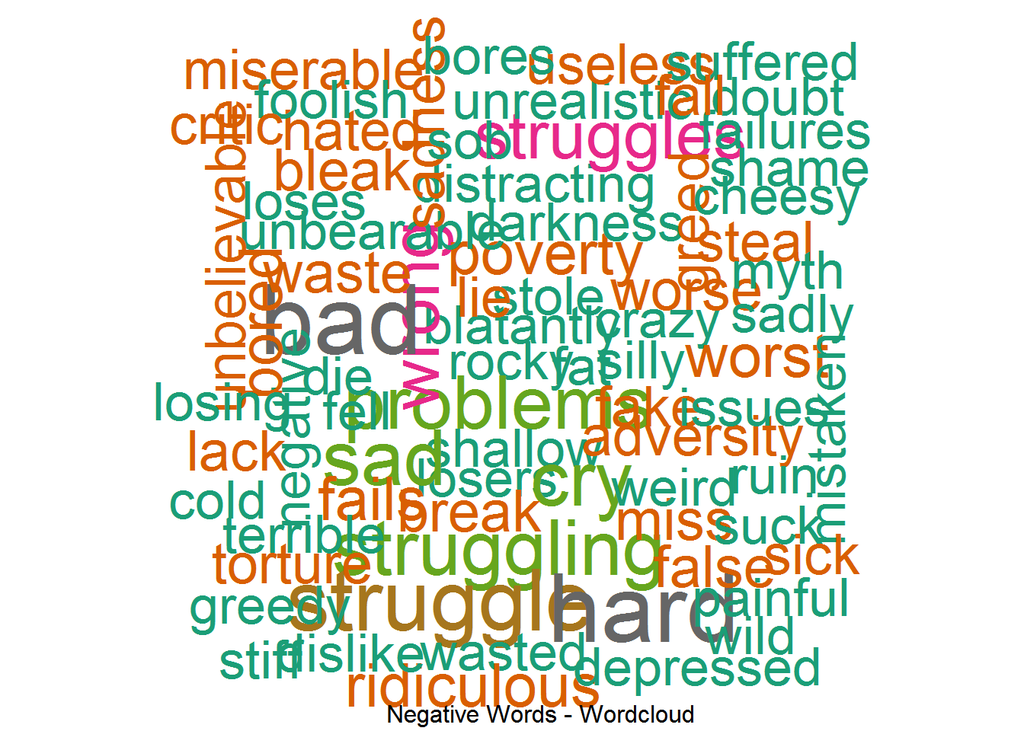

```r
neg.tdm = dtm[,which(colnames(dtm) %in% negative_words) ]
m = as.matrix(neg.tdm)
v = sort(colSums(m), decreasing = TRUE)
windows()
wordcloud(names(v), v, scale=c(4,2),1, max.words=100,colors=brewer.pal(8, "Dark2"))
title(sub = "Negative Words - Wordcloud")
```

```r
#print("Average sentiment across the corpus")
#print(pol$group$ave.polarity)
#print("with Standard Deviation")
#print(pol$group$sd.polarity)
pol$group
```

```
##   all total.sentences total.words ave.polarity sd.polarity
## 1 all             100        6563    0.2331527   0.8154162
##   stan.mean.polarity
## 1          0.2859308
```

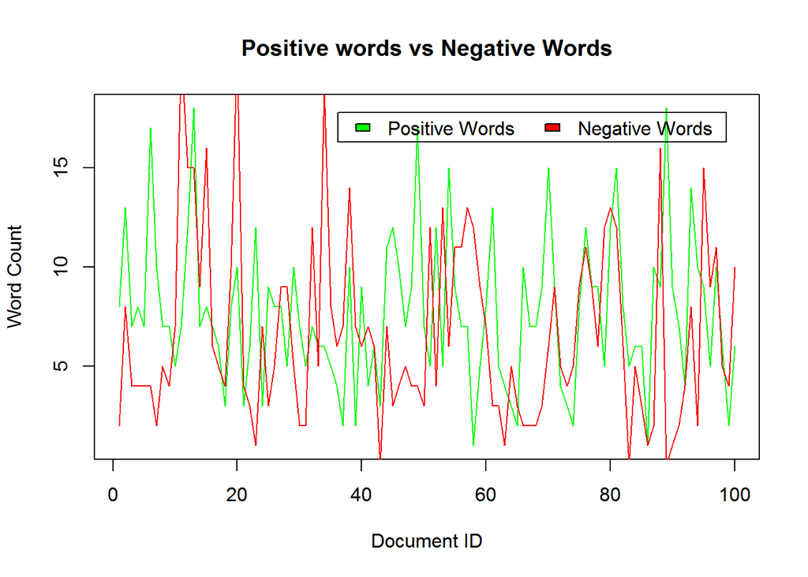

```r
len = function(x){
  if ( x == "-" && length(x) == 1)  {return (0)}
  else {return(length(unlist(x)))}
}
pcount = unlist(lapply(pol$all[,4], len))
ncount = unlist(lapply(pol$all[,5], len))
doc_id = seq(1:length(pol$all[,2]))
windows()
plot(doc_id,pcount,type="l",col="green",xlab = "Document ID", ylab= "Word Count")
lines(doc_id,ncount,type= "l", col="red")
title(main = "Positive words vs Negative Words" )
legend("topright", inset=.05, c("Positive Words","Negative Words"), fill=c("green","red"), horiz=TRUE)
```

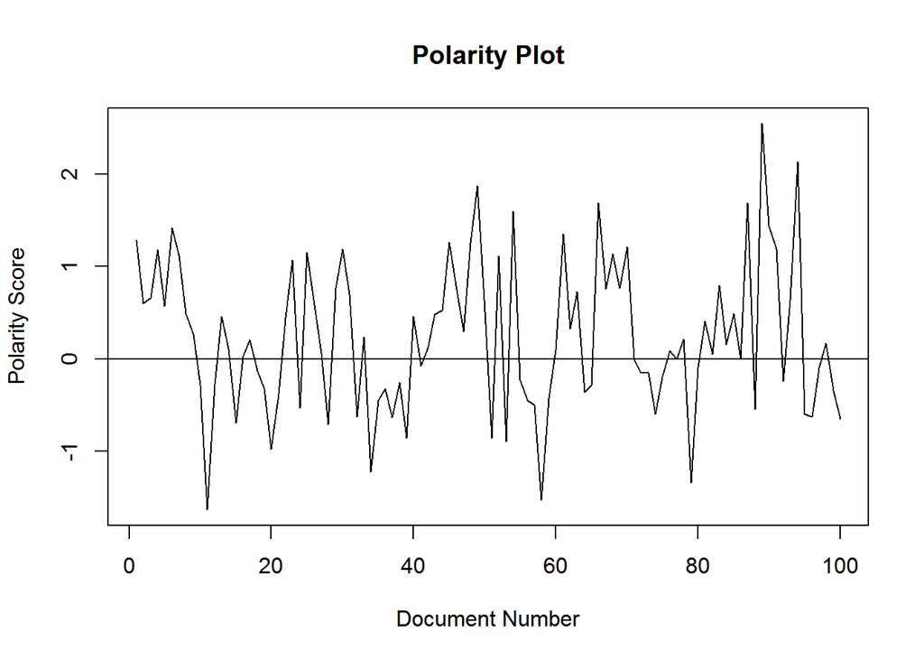

```r
plot(pol$all$polarity, type = "l", ylab = "Polarity Score",xlab = "Document Number")
abline(h=0)
title(main = "Polarity Plot" )
```

# Step - 5: Recommendation based on the analysis.

The movie that is considered here is *The Pursuit of Happyness*. This Movie was a based on real time story of a stock brocker, Chris Gartner, who faced several hurdles in his life’s journey towards success. This movie was released in 2006, featuring *Will Smith* in the lead role and was directed by *Gabriele Muccino*.

Based on the sample of 100 user reviews from the IMDB website, and analysing them we can observe the below patterns and make the below recommendations for the studio.

The main topics that audience were talking about are the: *Story, Employment/Job condition, The Father and Son relation, struggles in the life, connection between money and happiness*

The overall sample’s polarity score says that the movie has a positive impact based and most of viewers liked the movie. The corelation between the users ratings and the polarity score is 0.5, which means our analysis are cosiderably having strength.

Many Viewers said that the movie was great, intresting, inspiring, brillant, amazing, recommended, enjoyed. But there are also few of them who said that the movie was sad, depressing, struggles, crying, boring, ridiculous, misery.